```r
# Europe has high rates of life expectancy
# Asia and the Americas have high country sizes
```

2. (4pt) Make a similar plot, but this time use 2019 data only.

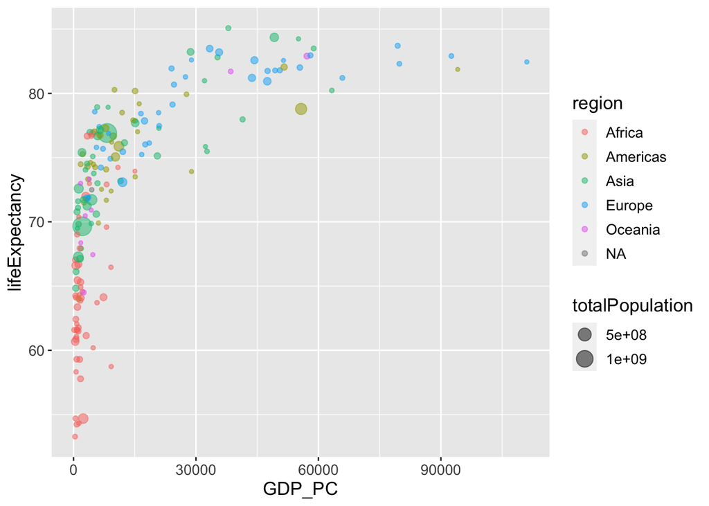

```r
gapminder %>%
  filter(time == 2019) %>%
  ggplot(aes(GDP_PC, lifeExpectancy, color = region, size = totalPopulation)) +
  geom_point(alpha=0.5) +
  labs(x = "GDP_PC",
        y = "lifeExpectancy") +
   theme(text = element_text(size=13))
```

3. (6pt) Compare these two plots and comment what do you see. How has world developed through the last 60 years?

```r
# The world has developed to have a higher life expectancy rate
# GDP per capita has also increased throughout the last 60 years
```

4. (6pt) Compute the average life expectancy for each continent in 1960 and 2019. Do the results fit with what do you see on the figures? Note: here as average I mean just average over countries, ignore the fact that countries are of different size.

```r
gapminder %>%
filter(time == 1960 | time == 2019) %>%
filter(!is.na(lifeExpectancy)) %>%
group_by(region, time) %>%
summarize(mean = mean(lifeExpectancy))
```

```
## # A tibble: 12 × 3
## # Groups:   region [6]
##    region    time  mean
##    <chr>    <dbl> <dbl>
##  1 Africa    1960  41.5
##  2 Africa    2019  64.1
##  3 Americas  1960  58.6
##  4 Americas  2019  75.8
##  5 Asia      1960  51.6
##  6 Asia      2019  74.6
##  7 Europe    1960  68.3
##  8 Europe    2019  79.4
##  9 Oceania   1960  56.4
## 10 Oceania   2019  73.5
## 11 <NA>      1960  70.7
## 12 <NA>      2019  77.8
```

```r
# Results match what is shown in the figures
```

5. (8pt) Compute the average LE growth from 1960-2019 across the continents. Show the results in the order of growth. Explain what do you see. Hint: these data (data in long form) is not the simplest to compute growth. But you may want to check out the lag() function. And do not forget to group data by continent when using lag(), otherwise your results will be messed up! See https://faculty.washington. edu/otoomet/info201-book/dplyr.html#dplyr-helpers-compute.

```r
gapminder %>%
  filter(time >= 1961) %>%
  group_by(region) %>%
  arrange(name, time) %>%
  mutate(avg_le = (lifeExpectancy - lag(lifeExpectancy)) / lag(lifeExpectancy)) %>%
  summarize(avg_growth = mean(avg_le, na.rm = TRUE)) %>%
  arrange(avg_growth)
```

```
## # A tibble: 6 × 2
##   region   avg_growth
##   <chr>         <dbl>
## 1 Europe     0.000483
## 2 Americas   0.00139
## 3 Asia       0.00153
## 4 Africa     0.00167
## 5 Oceania    0.00224
## 6 <NA>       0.0551
```

```r
# Oceania has the highest average life expectancy growth rate
```

6. (6pt) Show the histogram of GDP per capita for years of 1960 and 2019. Try to put both histograms on the same graph, see how well you can do it!

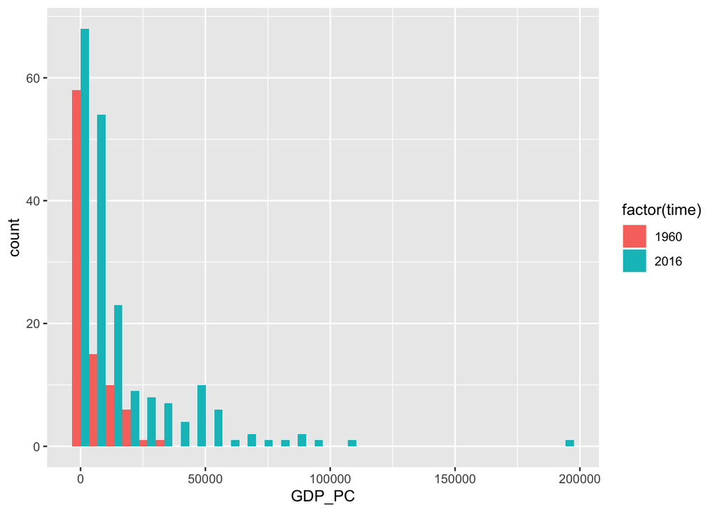

```r
gapminder %>%
  filter(time == 1960 | time == 2016) %>%
  ggplot(aes(GDP_PC, fill = factor(time))) +
  geom_histogram(position = "dodge")
```

7. (6pt) What was the ranking of US in terms of life expectancy in 1960 and in 2019? (When counting from top.) Hint: check out the function rank()! Hint2: 17 for 1960.

```r
gapminder %>%
  filter(time == 1960 | time == 2016) %>%
  filter(!is.na(lifeExpectancy)) %>%
  filter(!is.na(region)) %>%
  mutate(rank = rank(-lifeExpectancy)) %>%
  filter(name == "United States of America")
```

```
## # A tibble: 2 × 26
##   iso3  name  iso2  region sub-r…¹ inter…²  time total…³ ferti…⁴ lifeE…⁵ child…⁶
##   <chr> <chr> <chr> <chr>  <chr>   <chr>   <dbl>   <dbl>   <dbl>   <dbl>   <dbl>
## 1 USA   Unit… US    Ameri… Northe… <NA>     1960  1.81e8    3.65    69.8    30.1
## 2 USA   Unit… US    Ameri… Northe… <NA>     2016  3.23e8    1.82    78.5     6.7
## # … with 15 more variables: youthFemaleLiteracy <dbl>, youthMaleLiteracy <dbl>,
## #   adultLiteracy <dbl>, GDP_PC <dbl>, accessElectricity <dbl>,
## #   agriculturalLand <dbl>, agricultureTractors <dbl>, cerealProduction <dbl>,
## #   fertilizerHa <dbl>, co2 <dbl>, greenhouseGases <dbl>, co2_PC <dbl>,
## #   pm2.5_35 <dbl>, battleDeaths <dbl>, rank <dbl>, and abbreviated variable
## #   names ¹`sub-region`, ²`intermediate-region`, ³totalPopulation,
## #   ⁴fertilityRate, ⁵lifeExpectancy, ⁶childMortality
```

8. (6pt) If you did this correctly, then you noticed that US ranking has been falling quite a bit. But we also have more countries in 2019–what about the relative rank divided by the corresponding number of countries that have LE data in the corresponding year? Hint: 0.0904 for 1960.

```r
gapminder %>%
  filter(time == 1960) %>%
  filter(!is.na(lifeExpectancy)) %>%
  filter(!is.na(region)) %>%
  mutate(le_rank = rank(desc(lifeExpectancy)), nc = n(), re_rank = nc/le_rank) %>%
  filter(name == "United States of America")
```

```
## # A tibble: 1 × 28
##   iso3  name  iso2  region sub-r…¹ inter…²  time total…³ ferti…⁴ lifeE…⁵ child…⁶
##   <chr> <chr> <chr> <chr>  <chr>   <chr>   <dbl>   <dbl>   <dbl>   <dbl>   <dbl>
## 1 USA   Unit… US    Ameri… Northe… <NA>     1960  1.81e8    3.65    69.8    30.1
## # … with 17 more variables: youthFemaleLiteracy <dbl>, youthMaleLiteracy <dbl>,
## #   adultLiteracy <dbl>, GDP_PC <dbl>, accessElectricity <dbl>,
## #   agriculturalLand <dbl>, agricultureTractors <dbl>, cerealProduction <dbl>,
## #   fertilizerHa <dbl>, co2 <dbl>, greenhouseGases <dbl>, co2_PC <dbl>,
## #   pm2.5_35 <dbl>, battleDeaths <dbl>, le_rank <dbl>, nc <int>, re_rank <dbl>,
## #   and abbreviated variable names ¹`sub-region`, ²`intermediate-region`,
## #   ³totalPopulation, ⁴fertilityRate, ⁵lifeExpectancy, ⁶childMortality
```

**Finally tell us how many hours did you spend on this PS.**

```r
# About 10 hours
```